# Assignment 7, lab 3, group 6

Juan Moreno Diez, Letícia Marçal Russo, Luc Lubbers

28 octubre, 2022

# 1 Libraries

```r
library(tidyverse)
library(text2vec)
library(tm)
library(NLP)
library(SnowballC)
library(e1071)
library(caret)
library(pROC)
library(ROCR)
library(DALEX)
library(knitr)
```

# 2 The IMDB dataset

IMDB movie reviews is a labeled data set available within the text2vec package. This data set consists of 5000 IMDB movie reviews, specifically selected for sentiment analysis. The sentiment of the reviews is binary, meaning an IMDB rating < 5 results in a sentiment score of 0, and a rating >=7 has a sentiment score of 1. No individual movie has more than 30 reviews.

## 2.1 Corpus and data preprocessing

Now we will load the data and preprocess it by creating a corpus and then generating the TF and TFiDF matrices.

## 2.2 Loading data and creation of corpus

```r
data("movie_review")

# creation of the corpus
review_corpus <- VCorpus(VectorSource(movie_review$review))
```

In order to reduce the dimension of the document term matrix, we will remove the terms that are less frequent such that we get a sparsity smaller than 95%.

## 2.3 Data preprocessing: TF matrix

```r
# tf matrix with all the preprocessing
review_tf <- DocumentTermMatrix(review_corpus, control = list(
  tolower = TRUE,
  removeNumbers = TRUE,
  stopwords = TRUE,
  removePunctuation = TRUE,
  stemming = TRUE
))

# reducing sparsity
review_tf <- removeSparseTerms(review_tf, 0.95)
inspect(review_tf)
```

```
## <<DocumentTermMatrix (documents: 5000, terms: 378)>>
## Non-/sparse entries: 214970/1675030
## Sparsity           : 89%
## Maximal term length: 10
## Weighting          : term frequency (tf)
## Sample             :
##       Terms
## Docs   charact film get good just like make movi one time
##   215        1   27   4   11    2    3    1    7   5    2
##   2208       2    7   3    5    6   10    2   17   4    1
##   3188       7   15   7    0    2    4    4    9   4    0
##   3486       0    0  10    1    2    4    2    0   6    4
##   3876       0   11   4    3    6    5    1    9   3    6
##   4234       2    1   3    2    2    4    1   14   3    4
##   4321       6   23   2    3    4    2    3    0   1    2
##   4406       2    0   1    2    3    4    5   11  18    3
##   4850      10    1   7    0    3    2    5    0   4    8
##   4934       3    0   1    5    3    4    6    2   5    2
```

## 2.4 Data preprocessing: TF-IDF matrix

Now we will follow the same procedure to create a matrix for TF-IDF. The difference is the arguments “weighting = weightTfIdf” in the function DocumentTermMatrix().

```r
# tfidf matrix with all the preprocessing
review_tfidf <- DocumentTermMatrix(review_corpus, control = list(
  tolower = TRUE,
  removeNumbers = TRUE,
  stopwords = TRUE,
  removePunctuation = TRUE,
  stemming = TRUE,
  weighting = weightTfIdf
))

# reducing sparsity
review_tfidf <- removeSparseTerms(review_tfidf, 0.95)
inspect(review_tfidf)
```

```
## <<DocumentTermMatrix (documents: 5000, terms: 378)>>
## Non-/sparse entries: 214970/1675030
## Sparsity           : 89%
## Maximal term length: 10
## Weighting          : term frequency - inverse document frequency (normalized) (tf-idf)
## Sample             :
##       Terms
## Docs         film       good       just       like       movi        one
##   105  0.00000000 0.00000000 0.00000000 0.00000000 0.00000000 0.03304932
##   156  0.00000000 0.09451810 0.00000000 0.00000000 0.01516266 0.01921472
##   1713 0.00000000 0.00000000 0.00000000 0.04745437 0.03104735 0.00000000
##   2585 0.06935541 0.00000000 0.00000000 0.00000000 0.00000000 0.00000000
##   2605 0.07022235 0.04233623 0.00000000 0.00000000 0.00000000 0.00000000
##   2653 0.00000000 0.00000000 0.00000000 0.00000000 0.04829587 0.01530061
##   2797 0.00000000 0.01441233 0.04003051 0.01060151 0.00000000 0.00000000
##   3835 0.05761834 0.00000000 0.00000000 0.00000000 0.02507670 0.00000000
##   4167 0.00000000 0.04515865 0.04180965 0.00000000 0.04346628 0.02754110
##   4832 0.00000000 0.00000000 0.00000000 0.00000000 0.04657102 0.00000000
##       Terms
## Docs          see       show      stori      watch
##   105  0.05828789 0.00000000 0.00000000 0.05934325
##   156  0.00000000 0.00000000 0.00000000 0.00000000
##   1713 0.00000000 0.00000000 0.00000000 0.03532337
##   2585 0.00000000 0.00000000 0.00000000 0.00000000
##   2605 0.04553741 0.00000000 0.05324029 0.00000000
##   2653 0.00000000 0.00000000 0.00000000 0.00000000
##   2797 0.01550210 0.04721136 0.00000000 0.01578278
##   3835 0.00000000 0.00000000 0.00000000 0.00000000
##   4167 0.00000000 0.00000000 0.00000000 0.00000000
##   4832 0.05204276 0.00000000 0.00000000 0.00000000
```

## 2.5 Data splitting

Next we will split the data it into training (80%) and test (20%) sets.

```r
# splitting the date into 80% train and 20% test
# it doesnt matter whether we do the sample from the
# tf or the tfidf matrix, we just need the same indexes
indexes <- sort(sample(nrow(review_tf), nrow(review_tf)*.8))

# training sets for the tf matrixes
train_tf <- review_tf[indexes,]
test_tf <- review_tf[-indexes,]

# test sets for the tfidf matrixes
train_tfidf <- review_tfidf[indexes,]
test_tfidf <- review_tfidf[-indexes,]

# get the sentiment labels from both sets
labels_train <- as.factor(movie_review$sentiment[indexes])
labels_test <- as.factor(movie_review$sentiment[-indexes])

# check
str(train_tf)
```

```
## List of 6
##  $ i       : int [1:172910] 1 1 1 1 1 1 1 1 1 1 ...
##  $ j       : int [1:172910] 6 7 13 19 27 29 38 41 46 47 ...
##  $ v       : num [1:172910] 1 1 2 1 1 3 1 1 1 1 ...
##  $ nrow    : int 4000
##  $ ncol    : int 378
##  $ dimnames:List of 2
##   ..$ Docs : chr [1:4000] "1" "2" "4" "5" ...
##   ..$ Terms: chr [1:378] "absolut" "act" "action" "actor" ...
##  - attr(*, "class")= chr [1:2] "DocumentTermMatrix" "simple_triplet_matrix"
##  - attr(*, "weighting")= chr [1:2] "term frequency" "tf"
```

```r
str(test_tf)
```

```
## List of 6
##  $ i       : int [1:42060] 1 1 1 1 1 1 1 1 1 1 ...
##  $ j       : int [1:42060] 22 29 32 33 36 41 65 69 78 79 ...
##  $ v       : num [1:42060] 1 1 1 1 1 1 1 2 1 1 ...
##  $ nrow    : int 1000
##  $ ncol    : int 378
##  $ dimnames:List of 2
##   ..$ Docs : chr [1:1000] "3" "6" "8" "24" ...
##   ..$ Terms: chr [1:378] "absolut" "act" "action" "actor" ...
##  - attr(*, "class")= chr [1:2] "DocumentTermMatrix" "simple_triplet_matrix"
##  - attr(*, "weighting")= chr [1:2] "term frequency" "tf"
```

# 3 Supervised learning: classification

The two different document-term matrices we created will serve as input to a classifier, predicting the sentiment.

We will work with Naïve Bayes and Support Vector Machines.

## 3.1 Naïve Bayes

### 3.1.1 TF

In this section we will work with Naïve Bayes, starting with TF.

We will now run the model.

```r
set.seed(123)
# wrap up the dtm, otherwise it doesnt work
# training of the Naive Bayes model
naive_tf <- naiveBayes(as.matrix(train_tf), labels_train)
```

And make the prediction and confusion matrix for the train set.

```r
# prediction with the training set
pred_tf_train_nb <- predict(naive_tf, as.matrix(train_tf))
confusionMatrix(labels_train, pred_tf_train_nb)
```

```
## Confusion Matrix and Statistics
##
##           Reference
## Prediction    0    1
##          0 1563  434
##          1  349 1654
##
##                Accuracy : 0.8042
##                  95% CI : (0.7916, 0.8164)
##     No Information Rate : 0.522
##     P-Value [Acc > NIR] : < 2.2e-16
##
##                   Kappa : 0.6085
##
##  Mcnemar's Test P-Value : 0.002683
##
##             Sensitivity : 0.8175
##             Specificity : 0.7921
##          Pos Pred Value : 0.7827
##          Neg Pred Value : 0.8258
##              Prevalence : 0.4780
##          Detection Rate : 0.3907
##    Detection Prevalence : 0.4993
##       Balanced Accuracy : 0.8048
##
##        'Positive' Class : 0
##
```

#### 3.1.1.1 Performance: test set

Now we will check the performance in the test set.

```r
# prediction with the test set
pred_tf_test_nb <- predict(naive_tf, as.matrix(test_tf))
cm_tf_nb <- confusionMatrix(labels_test, pred_tf_test_nb)
```

### 3.1.2 TF-IDF

We will do the same procedure now for the TF-IDF matrix.

```r
set.seed(123)
# fit the model to the training set
naive_tfidf <- naiveBayes(as.matrix(train_tfidf), labels_train)
```

Prediction and confusion matrix for the train set:

```r
# prediction with the training set
pred_tfidf_nb <- predict(naive_tfidf, as.matrix(train_tfidf))
confusionMatrix(labels_train, pred_tfidf_nb)
```

```
## Confusion Matrix and Statistics
##
##           Reference
## Prediction    0    1
##          0 1562  435
##          1  352 1651
##
##                Accuracy : 0.8032
##                  95% CI : (0.7906, 0.8155)
##     No Information Rate : 0.5215
##     P-Value [Acc > NIR] : < 2.2e-16
##
##                   Kappa : 0.6065
##
##  Mcnemar's Test P-Value : 0.003467
##
##             Sensitivity : 0.8161
##             Specificity : 0.7915
##          Pos Pred Value : 0.7822
##          Neg Pred Value : 0.8243
##              Prevalence : 0.4785
##          Detection Rate : 0.3905
##    Detection Prevalence : 0.4993
##       Balanced Accuracy : 0.8038
##
##        'Positive' Class : 0
##
```

Now we will check the performance in the test set.

```r
# prediction with the test set
pred_tfidf_test_nb <- predict(naive_tfidf, as.matrix(test_tfidf))
cm_tfidf_nb <- confusionMatrix(labels_test, pred_tfidf_test_nb)
```

## 3.2 SVM

Now we will run a second model with support vector machine (SVM).

### 3.2.1 TF

We will start with TF.

```r
# train svm model with term-frequency data
svm_model_tf <- svm(y = labels_train,
                    x = as.matrix(train_tf),
                    type = "nu-classification",
                    ker = "linear")

# predicting
pred_tf_train_svm <- predict(svm_model_tf, as.matrix(train_tf))
# results in the train data
confusionMatrix(labels_train, pred_tf_train_svm)
```

```
## Confusion Matrix and Statistics
##
##           Reference
## Prediction    0    1
##          0 1673  324
##          1  265 1738
##
##                Accuracy : 0.8528
##                  95% CI : (0.8414, 0.8636)
##     No Information Rate : 0.5155
##     P-Value [Acc > NIR] : < 2e-16
##
##                   Kappa : 0.7055
##
##  Mcnemar's Test P-Value : 0.01686
##
##             Sensitivity : 0.8633
##             Specificity : 0.8429
##          Pos Pred Value : 0.8378
##          Neg Pred Value : 0.8677
##              Prevalence : 0.4845
##          Detection Rate : 0.4183
##    Detection Prevalence : 0.4993
##       Balanced Accuracy : 0.8531
##
##        'Positive' Class : 0
##
```

Now we will check the performance in the test set.

```r
# predicting
pred_tf_test_svm <- predict(svm_model_tf, as.matrix(test_tf))
# results in the test data
cm_tf_svm <- confusionMatrix(labels_test, pred_tf_test_svm)
```

### 3.2.2 TF-iDF

Now, SVM with TF-iDF.

```r
set.seed(123)

# train svm model with tf-idf data
svm_model_tfidf <- svm(y = labels_train,
                    x = as.matrix(train_tfidf),
                    type = "nu-classification",
                    ker = "linear")

# predicting
pred_tfidf_train_svm <- predict(svm_model_tfidf, as.matrix(train_tfidf))

# results in the train data
confusionMatrix(labels_train, pred_tfidf_train_svm)
```

```
## Confusion Matrix and Statistics
##
##           Reference
## Prediction    0    1
##          0 1690  307
##          1  278 1725
##
##                Accuracy : 0.8538
##                  95% CI : (0.8424, 0.8646)
##     No Information Rate : 0.508
##     P-Value [Acc > NIR] : <2e-16
##
##                   Kappa : 0.7075
##
##  Mcnemar's Test P-Value : 0.247
##
##             Sensitivity : 0.8587
##             Specificity : 0.8489
##          Pos Pred Value : 0.8463
##          Neg Pred Value : 0.8612
##              Prevalence : 0.4920
##          Detection Rate : 0.4225
##    Detection Prevalence : 0.4993
##       Balanced Accuracy : 0.8538
##
##        'Positive' Class : 0
##
```

Now we will check the performance in the test set.

```r
# predicting
pred_tfidf_test_svm <- predict(svm_model_tfidf, as.matrix(test_tfidf))
# results in the train data
cm_tfidf_svm <- confusionMatrix(labels_test, pred_tfidf_test_svm)
```

# 4 Comparison of models

## 4.1 ROC curve and AUC

### 4.1.1 TF Naive Bayes

```r
# necessary for processing the predictions from naive bayes
predvec_tf_nb <- ifelse(pred_tf_test_nb=="1", 1, 0)
# Use observed values against predicted values to make the roc curve
pred_roc_tf_nb <- prediction(predvec_tf_nb, labels_test)

roc_curve_1 <- performance(pred_roc_tf_nb, measure = "tpr", x.measure = "fpr")
auc_tf_nb <- auc(labels_test, predvec_tf_nb)
print(auc_tf_nb)
```

```
## Area under the curve: 0.781
```

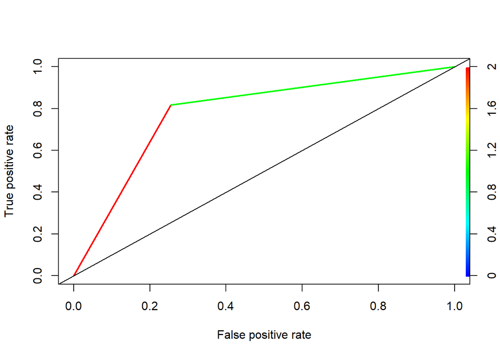

```r
plot(roc_curve_1, colorize = T, lwd = 2)
abline(a = 0, b = 1)
```

### 4.1.2 TFiDF Naive Bayes

```r
# necessary for processing the predictions from Naive Bayes
predvec_tfidf_nb <- ifelse(pred_tfidf_test_nb=="1", 1, 0)
# Use observed values against predicted values to make the roc curve
pred_roc_tfidf_nb <- prediction(predvec_tfidf_nb, labels_test)

roc_curve_2 <- performance(pred_roc_tfidf_nb, measure = "tpr", x.measure = "fpr")
auc_tfidf_nb <- auc(labels_test, predvec_tfidf_nb)
print(auc_tfidf_nb)
```

```
## Area under the curve: 0.7613
```

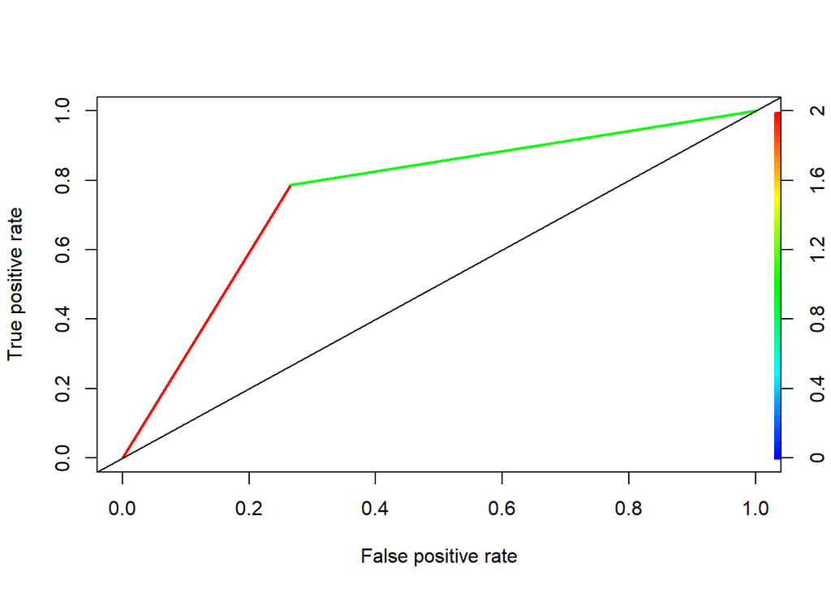

```r
plot(roc_curve_2, colorize = T, lwd = 2)
abline(a = 0, b = 1)
```

### 4.1.3 TF SVM

```r
# Use observed values against predicted values to make the roc curve
predvec_tf_svm <- ifelse(pred_tf_test_svm=="1", 1, 0)
pred_roc_tf_svm <- prediction(predvec_tf_svm, labels_test)

roc_curve_3 <- performance(pred_roc_tf_svm, measure = "tpr", x.measure = "fpr")
auc_tf_svm <- auc(labels_test, predvec_tf_svm)
print(auc_tf_svm)
```

```
## Area under the curve: 0.8064
```

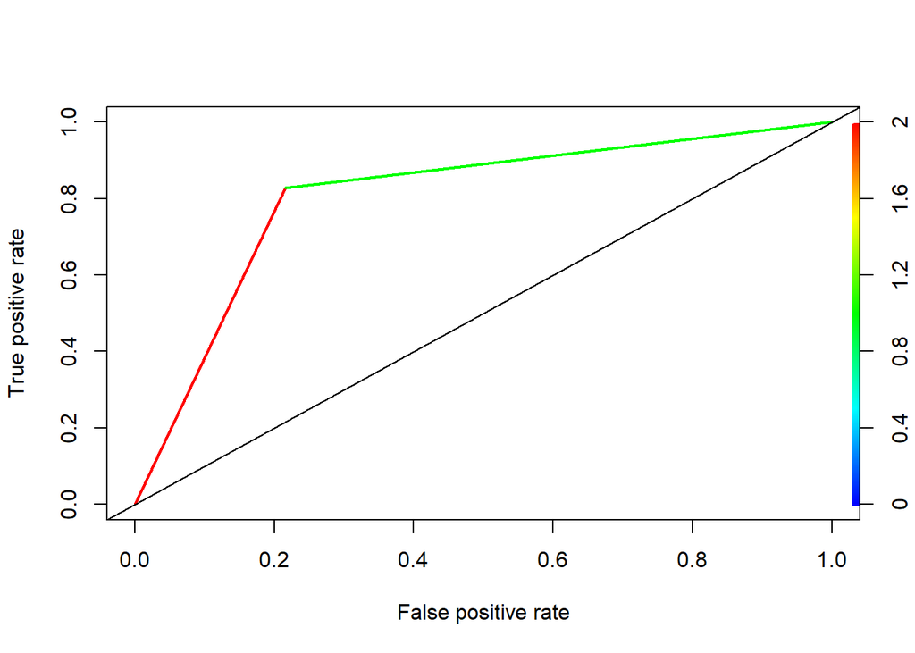

```r
plot(roc_curve_3, colorize = T, lwd = 2)
abline(a = 0, b = 1)
```

### 4.1.4 TFiDF SVM

```r
# Use observed values against predicted values to make the roc curve
predvec_tfidf_svm <- ifelse(pred_tfidf_test_svm=="1", 1, 0)
pred_roc_tfidf_svm <- prediction(predvec_tfidf_svm, labels_test)

roc_curve_4 <- performance(pred_roc_tfidf_svm, measure = "tpr", x.measure = "fpr")
auc_tfidf_svm <- auc(labels_test, predvec_tfidf_svm)
print(auc_tfidf_svm)
```

```
## Area under the curve: 0.7935
```

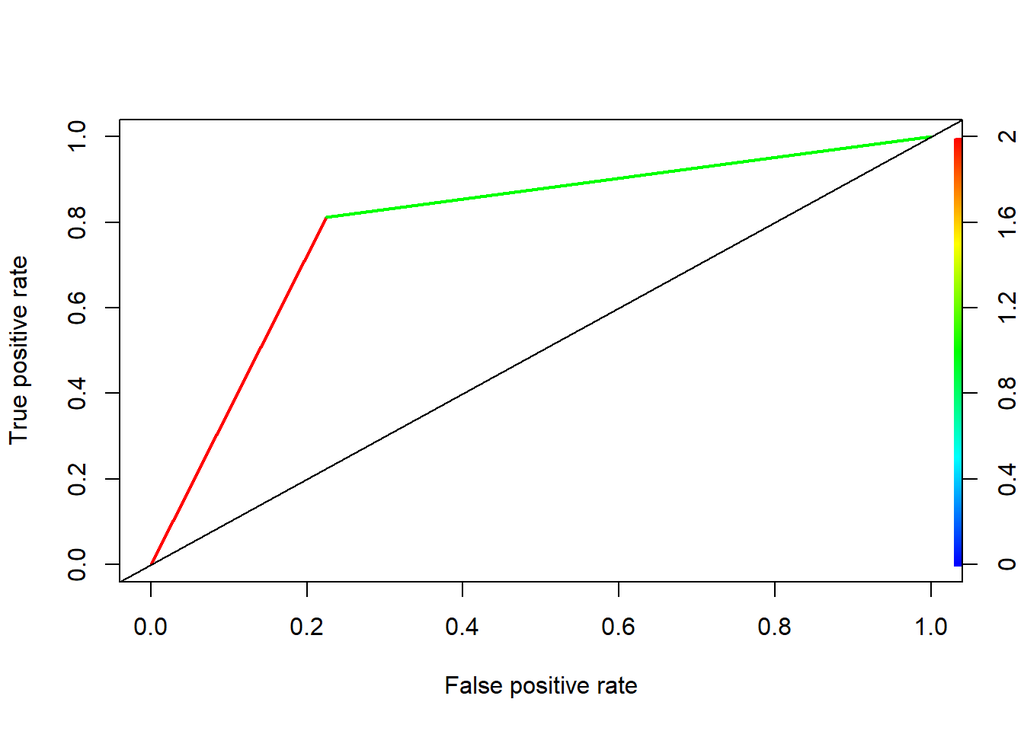

```r
plot(roc_curve_4, colorize = T, lwd = 2)
abline(a = 0, b = 1)
```

## 4.2 Loss: log-binary

### 4.2.1 TF Naive Bayes

```r
loss_tf_nb <- lares::loglossBinary(as.numeric(labels_test),
                                   as.numeric(pred_tf_test_nb))
print("Loss:")
```

```
## [1] "Loss:"
```

```r
print(loss_tf_nb)
```

```
## [1] -3.549071
```

### 4.2.2 TFiDF Naive Bayes

```r
loss_tfidf_nb <- lares::loglossBinary(as.numeric(labels_test),
                                      as.numeric(pred_tfidf_test_nb))
print("Loss:")
```

```
## [1] "Loss:"
```

```r
print(loss_tfidf_nb)
```

```
## [1] -3.549071
```

### 4.2.3 TF SVM

```r
loss_tf_svm <- lares::loglossBinary(as.numeric(labels_test),
                                    as.numeric(pred_tf_test_svm))
print("Loss:")
```

```
## [1] "Loss:"
```

```r
print(loss_tf_svm)
```

```
## [1] -3.549071
```

### 4.2.4 TFiDF SVM

```r
loss_tfidf_svm <- lares::loglossBinary(as.numeric(labels_test),
                                       as.numeric(pred_tfidf_test_svm))
print("Loss:")
```

```
## [1] "Loss:"
```

```r
print(loss_tfidf_svm)
```

```
## [1] -3.549071
```

# 5 Results

## 5.1 Table of metrics for Naive Bayes

```r
tab_nb <- matrix(c(cm_tf_nb$overall["Accuracy"], cm_tfidf_nb$overall["Accuracy"], loss_tf_nb,
                   loss_tfidf_nb, auc_tf_nb, auc_tf_nb), ncol =3)
colnames(tab_nb) <- c('Accuracy', 'Loss', 'AUC')
rownames(tab_nb) <- c('TF', 'TFiDF')

kable(tab_nb)
```

[output not shown]

## 5.2 Table of metrics for SVM

```r
tab_svm <- matrix(c(cm_tf_svm$overall["Accuracy"], cm_tfidf_svm$overall["Accuracy"], loss_tf_svm, loss_tfidf_svm, auc_tf_svm, auc_tfidf_svm), ncol =3)
colnames(tab_svm) <- c('Accuracy', 'Loss', 'AUC')
rownames(tab_svm) <- c('TF', 'TFiDF')

kable(tab_svm)
```

|  | Accuracy | Loss | AUC |
| --- | --- | --- | --- |
| TF | 0.807 | -3.549072 | 0.8063722 |
| TFiDF | 0.794 | -3.549072 | 0.7935021 |

## 5.3 Which model performs better?

The Accuracy of the TF representation is higher (higher accuracy = better). In the Naive Bayes model, the loss is negative for both representations. The Area Under Curve (AUC) for the TFiDF representation is a little bit lower. The closer the AUC is to 1, the better the model.

We can conclude that the TF representation performs better than TFiDF. Although the difference between both of them is not that big, it could be taken into account when performing with larger datasets.